Interim Review Report 1 · section 10 programme

# Every relaxation fits better. Only one moves the answer.

Four bounded diagnostics on the Outside Pacific Spiny Dogfish assessment, plus a multi-start of all 21 published configurations.

**To**

Sean Cox

**From**

S.D.N. Johnson, Landmark Fisheries Research

**Date**

25 August 2026

**Subject**

Anderson et al. (2026), DFO CSAS Res. Doc. 2025/055

## Two findings

**A0’s depletion is conditional on its deterministic structure.** Allowing recruitment to vary moves 2023 depletion from 0.086 to 0.175, and improves the fit to *both* data components. The B-series reaches 0.157–0.172 by relaxing constant natural mortality instead. Independent relaxations land at roughly twice the base depletion.

**Constant M is simply the worse assumption.** Lorenzen mortality, with the same 46 estimated parameters, fits better on both data components — and leaves the status answer untouched.

Neither disturbs the low-abundance conclusion, which holds across everything run. What moves is the reconstructed unfished scale, and therefore the removal advice.

## And a problem that conditions all of it

This likelihood surface is strongly multi-modal, and the source is identifiable: the 24 sex-specific selectivity offsets. Counting how often 21 jittered starts reach each configuration’s best optimum — **the one configuration that optimises reliably is the one with those offsets switched off**.

Starts reaching the best optimum, of 21

| Configuration | Reaching best | Rate | Worst start |
| --- | --- | --- | --- |
| A0 | 6 | 29% | 5000 |
| D1 — sex selectivity fixed | **20** | **95%** | **1854** |
| D2 — no discard comps | 6 | 29% | 3391 |
| D3 — recruitment deviations | 1 | 5% | 3466 |

Cox’s section 5 suspected this structure was weakly identified. It is — and the evidence arrived from optimisation behaviour rather than from the data. Every number on this page is best-of-N as a result.

## Mortality structure — D4

`natM_type` switched from 0 to 2 (Lorenzen) with a reference age of 40, matching `Growth_Age_for_L2`. The supplied fixed M of 0.065 becomes M *at that age*, so only the shape changes and the parameter count is unchanged.

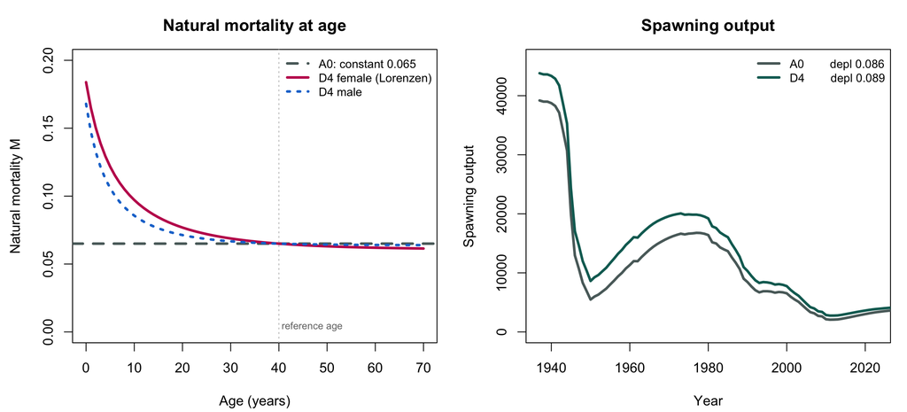

D4 gives a standard Lorenzen profile — high juvenile mortality falling toward the adult value. The trajectory sits above A0 through the middle of the series and converges by the terminal year, which is why the fit improves while depletion does not.

D4 against A0, identical parameter count

|  | A0 | D4 Lorenzen M |
| --- | --- | --- |
| Estimated parameters | 46 | 46 |
| Total objective | 1646.4 | 1562.2 |
| Survey | 922.5 | 876.6 |
| Length composition | 671.1 | 634.3 |
| Unfished spawning output | 39,194 | 43,805 |
| Depletion 2023 | 0.086 | 0.089 |

## Recruitment process — D3 and D3b

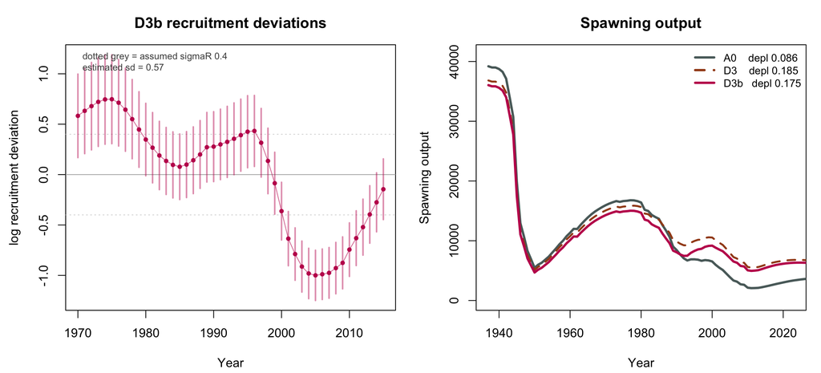

The deviations are not interannual noise. They form a smooth multi-decadal wave, and their standard deviation of 0.57 exceeds the assumed sigmaR of 0.4 — the model wants more recruitment variation than the prior permits, and wants it as a slow trend.

Recruitment variation, both windows

|  | A0 | D3 (1960–2022) | D3b (1970–2015) |
| --- | --- | --- | --- |
| Survey | 922.5 | 768.3 | 772.5 |
| Length composition | 671.1 | 643.9 | 650.0 |
| Recruitment penalty | 0.0 | 51.3 | 45.9 |
| Deviations estimated | 0 | 63 | 46 |
| Depletion 2023 | 0.086 | 0.185 | 0.175 |

That the deviations come out as a slow wave rather than noise is worth dwelling on. It is the same low-frequency signal the B-series captures by increasing natural mortality instead. Two different structural stories, one shared pattern in the data.

## Status across the diagnostics

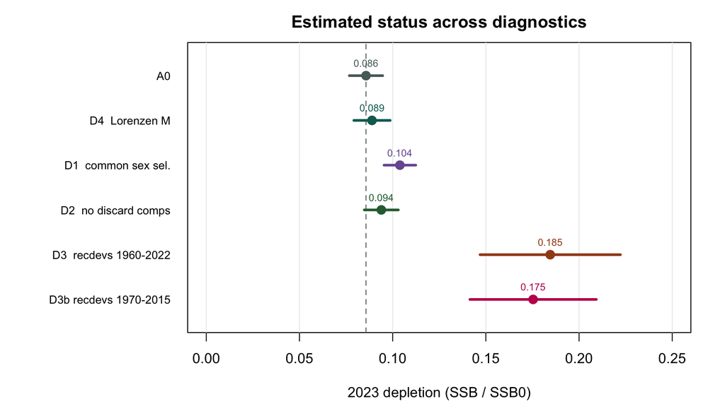

Only the recruitment diagnostics move status, and they move it decisively — with wider intervals, as they should. Everything else sits within a point or two of the base.

## The other two diagnostics

### D1 Common sex selectivity

Fixing the four estimated male offsets on each of the six pattern-24 fleets takes the model from 46 to 22 parameters; female and male selectivity then match to machine precision in all twelve fleets. The data reject it decisively — likelihood ratio 411.6 on 24 degrees of freedom, AIC 3384.8 against 3748.4 — but the structure carries a quarter of the estimated stock scale (unfished output 39,194 to 29,588), and removing it *raises* F rather than lowering it. Sex-specific selectivity is not inflating female fishing mortality.

The two results are in tension, and the tension is the point. The data prefer these curves by a wide margin; those same curves are what make the model unreliable to fit.

### D2 Discard length compositions

Dropping ten fleet-2 rows halves total 2023 F (0.0092 to 0.0047) while apical F on bottom trawl discards rises roughly eightfold (0.0107 to 0.0838). Fleet 2 drives the selectivity of four other fleets through the mirroring structure, so ten rows of data are load-bearing for five fleets. Concrete support for the section 9 position that removal-at-length allocation needs recalculating.

## The published configurations, multi-started

All 21 published A- and B-series configurations, 11 starts each. **Eleven sit more than 10 likelihood units above a better optimum**, three of them by roughly 650.

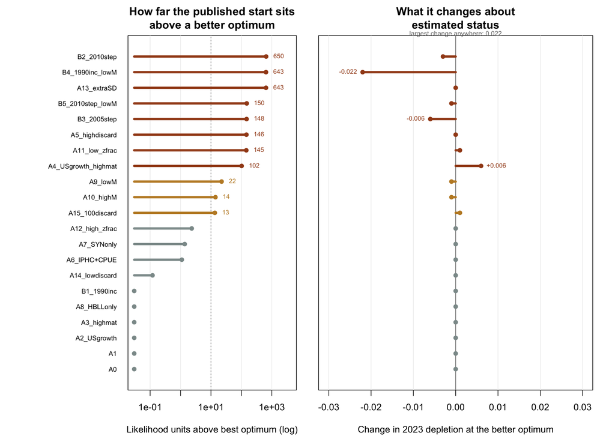

The left panel spans four orders of magnitude. The right panel, on the same ordering, spans almost nothing — the largest change in 2023 depletion anywhere is 0.022.

The penalty is almost entirely in the length compositions, every time. B2’s composition likelihood more than halves, 1194.0 to 537.9; A13’s falls 1304.4 to 641.3. Several published configurations are therefore reported with composition fits roughly twice as poor as the same configuration can achieve, which affects any composition-fit diagnostic, residual plot, or likelihood-based comparison drawn from those runs.

## The fair reading

This is a model-selection and diagnostics problem, not a status problem, and we would not want it reported as anything stronger. Stock status in the Research Document is robust to it. It matters because the section 10 programme, and any ensemble that weights models by fit, both depend on the part that is not reliable.

## Still open

- Old-age biology and trawl removals — deferred until the baseline is validated against the authors’ outputs, since both turn on absolute rather than relative quantities.
- A0 verification proper — blocked on those outputs. We can say our A0 converges and returns depletion 0.086 (SD 0.005) against the published 0.09, CI 0.08–0.09. We have not matched likelihood components, the parameter vector, warnings or gradients, because those files do not exist on our side.
- The comparison reviews — Gertseva et al. 2021, Taylor and Gallucci 2009, and the Northwest Atlantic assessment.

Configurations under `ss3/`: D1_commonsel, D2_nodiscardlen, D3_recdev, D3b_recdev_window, D4_lorenzenM. Multi-start harness `review/03-jitter.R`; figures `review/09-figures-diagnostics.R`. Every fit reported here is the best of N starts.